# Iterative methods

[AMath 585, Winter Quarter 2020](http://staff.washington.edu/rjl/classes/am585w2020/) at the University of Washington. Developed by R.J. LeVeque and distributed under the [BSD license](https://github.com/rjleveque/amath585w2020/blob/master/LICENSE). You are free to modify and use as you please, with attribution.

These notebooks are all [available on Github](https://github.com/rjleveque/amath585w2020/).

This notebook illustrates some classical iterative methods based on matrix splitting: Jacobi, Gauss-Seidel, and SOR.

```python
%matplotlib inline
```

```python
from pylab import *
```

To better illustrate the sequence of approximate solutions obtained as we iterate, we will use a widget to display a sequence of plots in a way that we can easily look through them. Other available widgets are described and illustrated in the [ipywidgets documentation](https://ipywidgets.readthedocs.io/en/latest/examples/Widget%20Basics.html).

The function `animate_figs` defined below invokes an iteractive widget to loop over a set of matplotlib figures that have been generated in some loop and stored as a list called `figs`:

```python
from ipywidgets import interact
import ipywidgets as widgets

def animate_figs(figs):
    show_frame = lambda frameno: display(figs[frameno])
    interact(show_frame, frameno=widgets.IntSlider(min=0,max=len(figs)-1, value=0))
```

## Define a simple BVP in 1D

For illustration we will solve $u''(x) = f(x)$ in $0\leq x \leq 1$ with Dirichlet boundary conditions.

We choose a cubic function $u(x)$ as the solution so that the truncation error is zero, and hence the exact solution of the linear system should be the exact solution of the ODE at the grid points.

```python
f_fcn = lambda x: 6*x + 2
utrue_fcn = lambda x: x**3 + x**2 - x + 1
```

This `solve_bvp` function sets up and solves the linear system by an iterative method that is defined by the argurment `update_u`, which should be a function to take a single step of some iterative method.

This allows us to easily test different methods by passing in a different `update_u` function, without repeating all the other stuff.

Note that this is set up to solve the system in which the tridiagonal matrix has been augmented by a row of the identity matrix at the top and bottom with right hand sides values given by the Dirichlet boundary conditions, i.e., the first and last equations in the system are `U[0] = alpha` and `U[m+1] = beta`. This is convenient for plotting purposes and also if you want to try modifying the problem to use Neumann BCs at one of the boundaries, for example.

```python
def solve_bvp(f_fcn, utrue_fcn, m, update_u, maxiter, kplot):

    alpha = utrue_fcn(0)
    beta = utrue_fcn(1)

    h = 1./(m+1)
    x = linspace(0,1,m+2)

    utrue = utrue_fcn(x)
    F = f_fcn(x)

    U0 = linspace(alpha, beta, m+2) # initial guess
    U = U0.copy() # current iterate

    max_error = abs(U-utrue).max()
    errors = [max_error]

    figs = []  # for the list of figures we generate

    for k in range(1,maxiter+1):

        U = update_u(U, F, h)  # take one iteration

        max_error = abs(U-utrue).max()
        errors.append(max_error)

        if mod(k,kplot)==0 or k==maxiter:
            # every kplot iterations create a plot:
            fig = figure(figsize=(12,5))
            plot(x,U0,'r-o', label='initial guess')
            plot(x,utrue,'k-o', label='true solution')
            plot(x,U,'bo-', label= 'iteration k = %i' % k)
            legend()
            grid(True)
            xlim(0,1)
            ylim(0, 3)
            title('After %i iterations, max error = %.2e' \
                  % (k, max_error))
            figs.append(fig)
            close(fig)

    errors = array(errors)  # convert list to numpy array
    return errors, figs
```

## Jacobi iteration

This function does one update step for Jacobi. Note that the way we have defined the system to include the boundary values, Jacobi does not change the first or last element of `U`.

```python
def update_u_Jacobi(U, F, h):
    """
    Input: Current iterate U^[k-1]
    Output: Next iterate U^[k]
    """
    m = len(U) - 2
    Uprev = U.copy()  # save current iterate so it's not overwritten

    for i in range(1,m+1):
        U[i] = 0.5*(Uprev[i-1] + Uprev[i+1] - h**2 * F[i])

    return U
```

```python
m = 19
h = 1./(m+1)
```

### Test Jacobi

If you adjust this to plot every iteration for say 20 iteration you will see that convergence is very slow. Here we plot every 20 iterations for 400:

```python
errors_Jacobi, figs = solve_bvp(f_fcn, utrue_fcn, m=m, update_u=update_u_Jacobi,
                                maxiter=400, kplot=20)
```

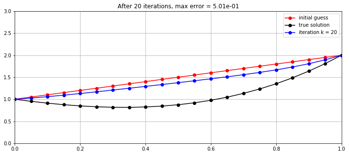

```python
animate_figs(figs)
```

## Gauss-Seidel iteration

For Gauss-Seidel we update `U[i]` using the already-updated `U[i-1]`.

```python
def update_u_GS(U, F, h):
    """
    Input: Current iterate U^[k-1]
    Output: Next iterate U^[k]
    """
    m = len(U) - 2
    for i in range(1,m+1):
        U[i] = 0.5*(U[i-1] + U[i+1] - h**2 * F[i])
    return U
```

```python
errors_GS, figs = solve_bvp(f_fcn, utrue_fcn, m=m, update_u=update_u_GS,
                            maxiter=400, kplot=20)
```

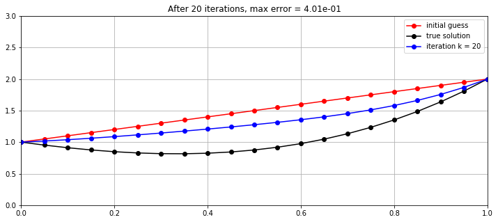

```python
animate_figs(figs)
```

We observe that Gauss-Seidel converges faster, as expected. If we plot the error vs. k, we can see that both are decaying exponentially, though slowly.

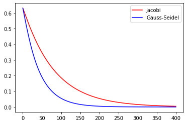

```python
plot(errors_Jacobi, 'r', label='Jacobi')
plot(errors_GS, 'b', label='Gauss-Seidel')
legend();
```

Since we expect the error to decay like $E(k) \approx C \rho^k$ for some convergence rate $\rho$, the rates are clearer if we make a semilogy plot. Since we expect $\log(E(k)) \approx \log(C) + k\log(\rho)$ we expect the error to decay linearly in such a plot with slope $\log(\rho) < 0$ since $\rho < 1$.

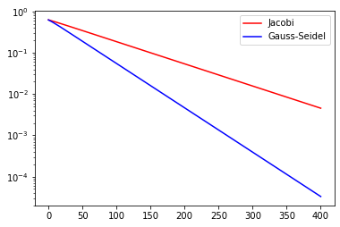

```python
semilogy(errors_Jacobi, 'r', label='Jacobi')
semilogy(errors_GS, 'b', label='Gauss-Seidel')
legend();
```

## Estimating the convergence rate

Since we expect $\log(E(k)) \approx \log(C) + k\log(\rho)$ and the convergence looks so linear, we could fit a straight line through a couple points on these plots and easily estimate $\log(\rho)$.

A more general approach, if the convergence is a bit ragged, would be to do a least squares fit of a linear function to more points (say $n$) from this convergence plot, setting up a linear system using $\log(E_i) = c_1 + c_2 k_i$ for $i=1,~2,~\ldots,~n$,

$$ \left[\begin{array}{cc} 1 & k_1\\ 1 & k_2\\ \vdots & \vdots \\ 1 & k_n \end{array}\right] \left[\begin{array}{c} c_1\\ c_2 \end{array}\right] = \left[\begin{array}{c} \log(E_1)\\ \log(E_2)\\ \vdots\\ \log(E_n) \end{array}\right] $$

and then solving this in the least squares sense for $[c_1,~c_2]$. Then $\rho \approx \exp(c_2)$.

Here we explicitly set up and solve this least square problem using [numpy.linalg.lstsq](https://docs.scipy.org/doc/numpy/reference/generated/numpy.linalg.lstsq.html).

```python
def convergence_rate(k_vals, errors):
    n = len(k_vals)
    assert len(errors) == n, 'k_vals and errors must have the same length'
    print('Estimating rate based on %i values' % n)
    B = vstack((ones(n),k_vals)).T
    logE = log(errors)

    # solve least square problem:
    c, residuals, rank, s = lstsq(B,logE,rcond=None)

    logC = c[0]
    logrho = c[1]
    C = exp(logC)
    rho = exp(logrho)
    print('Convergence approximately like  E(k) = %.3f * rho**k   with rho = %.8f' % (C,rho))
```

```python
k_vals = arange(50, 200, dtype=int)
rho_Jacobi = convergence_rate(k_vals, errors_Jacobi[k_vals])

# compare with the value expected from (4.16) in the text:
rho_theory = 1 - 0.5*pi**2*h**2
print('Predicted value of rho = %.8f' % rho_theory)
```

```
Estimating rate based on 150 values
Convergence approximately like  E(k) = 0.645 * rho**k   with rho = 0.98768885
Predicted value of rho = 0.98766299
```

```python
k_vals = arange(50, 200, dtype=int)
rho_GS = convergence_rate(k_vals, errors_GS[k_vals])

# compare with the value expected from (4.21) in the text:
rho_theory = 1 - pi**2*h**2
print('Predicted value of rho = %.8f' % rho_theory)
```

```
Estimating rate based on 150 values
Convergence approximately like  E(k) = 0.659 * rho**k   with rho = 0.97552826
Predicted value of rho = 0.97532599
```

## SOR method

The successive overrelaxation method computes the G-S update at each point but then moves farther in this direction. The optimal $\omega$ for this one-dimensional Poisson problem is given in Section 4.2.2.

```python
omega_opt = 2 / (1 + sin(pi*h))
print('Optimal omega = %.6f' % omega_opt)
```

```
Optimal omega = 1.729454
```

Here's the update method for SOR. You might want to try changing `omega` to different values to see how this affects convergence. It should converge as long as $0 < \omega < 2$ but even small changes in $\omega$ will give much poorer results than the optimal. (And recall that $\omega = 1$ corresponds to Gauss-Seidel, so setting $\omega < 1$ would be *under-relaxed* and converge even slower than G-S.)

```python
omega = omega_opt
#omega = 1.9

def update_u_SOR(U, F, h):
    """
    Input: Current iterate U^[k-1]
    Output: Next iterate U^[k]
    """
    m = len(U) - 2
    for i in range(1,m+1):
        U[i] = 0.5*(U[i-1] + U[i+1] - h**2 * F[i])*omega \
               + (1-omega)*U[i]
    return U
```

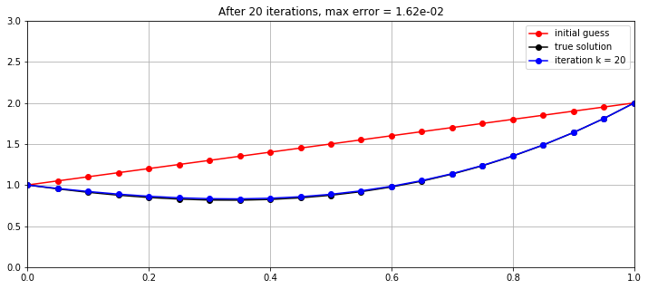

```python
errors_SOR, figs = solve_bvp(f_fcn, utrue_fcn, m=m, update_u=update_u_SOR,
                             maxiter=400, kplot=20)

animate_figs(figs)
```

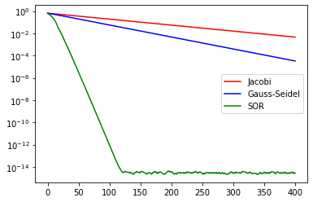

```python
semilogy(errors_Jacobi, 'r', label='Jacobi')
semilogy(errors_GS, 'b', label='Gauss-Seidel')
semilogy(errors_SOR, 'g', label='SOR')
legend();
```

```python
k_vals = arange(50, 100, dtype=int)
rho_SOR = convergence_rate(k_vals, errors_SOR[k_vals])

rho_theory = omega - 1  # only correct if omega_opt <= omega < 2
print('Predicted value of rho = %.8f' % rho_theory)
```

```
Estimating rate based on 50 values
Convergence approximately like  E(k) = 11.667 * rho**k   with rho = 0.73977834
Predicted value of rho = 0.72945382
```

## Try a different $f$ function

Remember that the iterative method is converging (we hope) to the solution of the linear system of equations, and **not** to the true solution of the differential equation in general. In the example above we chose a problem for which the truncation error is zero and so the two are ths same, but this is not true in general.

Here's a problem for which the numerical approximation to the ODE is not exact, and so if we compute the error as we did above by comparing to the true solution of the ODE it will not go to zero as we take more iterations. It will stop decreasing once the global error of the finite difference method is greater than the error in our approximation to the solution of the linear system:

```python
f_fcn = lambda x: -12*sin(2*x)
utrue_fcn = lambda x: 3*sin(2*x)
```

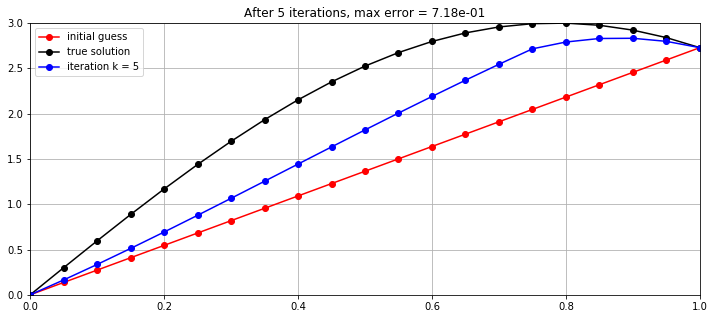

```python
errors_SOR, figs = solve_bvp(f_fcn, utrue_fcn, m=m, update_u=update_u_SOR,
                             maxiter=100, kplot=5)

animate_figs(figs)
```

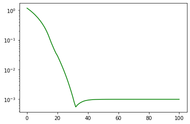

```python
semilogy(errors_SOR, 'g', label='SOR');
```

In this case, to get a better approximation to the ODE solution we would of course have to use a finer grid. Note that for SOR the optimal omega then has to be adjusted as well...

```python
m = 39
h = 1./(m+1)
omega_opt = 2 / (1 + sin(pi*h))
print('Optimal omega = %.6f' % omega_opt)
```

```
Optimal omega = 1.854498
```

```python
omega = omega_opt

def update_u_SOR(U, F, h):
    """
    Input: Current iterate U^[k-1]
    Output: Next iterate U^[k]
    """
    m = len(U) - 2
    for i in range(1,m+1):
        U[i] = 0.5*(U[i-1] + U[i+1] - h**2 * F[i])*omega \
               + (1-omega)*U[i]
    return U
```

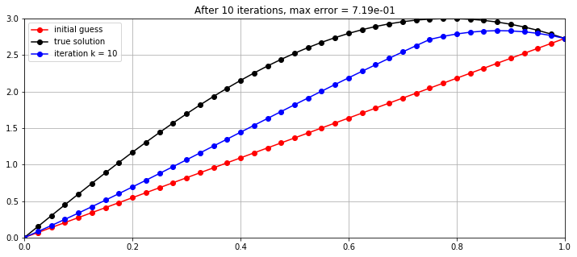

```python
errors_SOR, figs = solve_bvp(f_fcn, utrue_fcn, m=39, update_u=update_u_SOR,
                             maxiter=200, kplot=10)

animate_figs(figs)
```

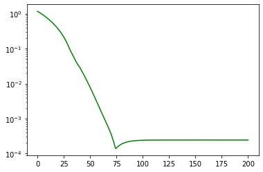

```python
semilogy(errors_SOR, 'g', label='SOR');
```